# PRACA RAMOWA NR 1: KLASYFIKATOR LINIOWY TENSOR FLOW

# Ćwiczenia na podstawie samouczka GURU99

### TensorFlow wersja 1.65?

https://www.guru99.com/linear-classifier-tensorflow.html

Co to jest liniowy klasyfikator? Dwa najczęściej nadzorowane zadania edukacyjne to regresja liniowa i liniowy klasyfikator. Regresja liniowa przewiduje wartość, a klasyfikator liniowy przewiduje klasę. Ten samouczek koncentruje się na klasyfikatorze liniowym.

#### Problemy z klasyfikacją stanowią około 80 procent zadania uczenia maszynowego. Klasyfikacja ma na celu przewidzenie prawdopodobieństwa każdej klasy na podstawie zestawu danych wejściowych.

Etykieta (tj. Zmienna zależna) jest wartością dyskretną, zwaną klasą.

- Jeśli etykieta ma tylko dwie klasy, algorytm uczenia się jest klasyfikatorem binarnym.
- Wieloklasowy klasyfikator obsługuje etykiety z więcej niż dwiema klasami.

Na przykład typowym problemem z klasyfikacją binarną jest przewidywanie prawdopodobieństwa, że klient dokona drugiego zakupu. Przewidywanie rodzaju zwierzęcia wyświetlanego na zdjęciu jest problemem klasyfikacji wieloklasowej, ponieważ istnieją więcej niż dwie odmiany zwierząt.

Część teoretyczna tego samouczka kładzie główny nacisk na klasę binarną. Dowiesz się więcej o funkcji wyjściowej wieloklasowej w przyszłym samouczku.

W tym samouczku nauczysz się - Co to jest liniowy klasyfikator?

```python
import tensorflow as tf
import pandas as pd
```

### Krok 1. Ściągamy dane

```python
## Define path data
COLUMNS = ['age','workclass', 'fnlwgt', 'education', 'education_num', 'marital',
           'occupation', 'relationship', 'race', 'sex', 'capital_gain', 'capital_loss',
           'hours_week', 'native_country', 'label']
#PATH_test = "https://archive.ics.uci.edu/ml/machine-learning-databases/adult/adult.test"
```

Dane przechowywane online są już podzielone między zestaw treningowy i zestaw testowy.

```python
df_train=pd.read_csv('c:/TF/adult.data', skipinitialspace=True, names = COLUMNS, index_col=False)
df_train.head(3)
```

|  | age | workclass | fnlwgt | education | education_num | marital | occupation | relationship | race | sex | capital_gain | capital_loss | hours_week | native_country | label |
| --- | --- | --- | --- | --- | --- | --- | --- | --- | --- | --- | --- | --- | --- | --- | --- |
| 0 | 39 | State-gov | 77516 | Bachelors | 13 | Never-married | Adm-clerical | Not-in-family | White | Male | 2174 | 0 | 40 | United-States | <=50K |
| 1 | 50 | Self-emp-not-inc | 83311 | Bachelors | 13 | Married-civ-spouse | Exec-managerial | Husband | White | Male | 0 | 0 | 13 | United-States | <=50K |
| 2 | 38 | Private | 215646 | HS-grad | 9 | Divorced | Handlers-cleaners | Not-in-family | White | Male | 0 | 0 | 40 | United-States | <=50K |

```python
df_test=pd.read_csv('c:/TF/adult.test',skiprows = 1, skipinitialspace=True, names = COLUMNS, index_col=False)
df_test.head(4)
```

|  | age | workclass | fnlwgt | education | education_num | marital | occupation | relationship | race | sex | capital_gain | capital_loss | hours_week | native_country | label |
| --- | --- | --- | --- | --- | --- | --- | --- | --- | --- | --- | --- | --- | --- | --- | --- |
| 0 | 25 | Private | 226802 | 11th | 7 | Never-married | Machine-op-inspct | Own-child | Black | Male | 0 | 0 | 40 | United-States | <=50K. |
| 1 | 38 | Private | 89814 | HS-grad | 9 | Married-civ-spouse | Farming-fishing | Husband | White | Male | 0 | 0 | 50 | United-States | <=50K. |
| 2 | 28 | Local-gov | 336951 | Assoc-acdm | 12 | Married-civ-spouse | Protective-serv | Husband | White | Male | 0 | 0 | 40 | United-States | >50K. |
| 3 | 44 | Private | 160323 | Some-college | 10 | Married-civ-spouse | Machine-op-inspct | Husband | Black | Male | 7688 | 0 | 40 | United-States | >50K. |

```python
print(df_train.shape, df_test.shape)
print(df_train.dtypes)
```

```
(32561, 15) (16281, 15)
age                int64
workclass         object
fnlwgt             int64
education         object
education_num      int64
marital           object
occupation        object
relationship      object
race              object
sex               object
capital_gain       int64
capital_loss       int64
hours_week         int64
native_country    object
label             object
dtype: object
```

## Krok 2. Tworzymy zmienną zależną, wynikową (label).

Ma ona postać tekstową - kodujemy ją na wartość 0, 1

```python
#label = {'<=50K': 0,'>50K': 1}
#df_train.label = [label[item] for item in df_train.label]

#label_t = {'<=50K.': 0,'>50K.': 1}
#df_test.label = [label_t[item] for item in df_test.label]
```

```python
df_train['label'] = df_train['label'].map({'<=50K':0, '>50K':1})
```

```python
df_train["label"].value_counts()
```

```
0    24720
1     7841
Name: label, dtype: int64
```

```python
df_train["label"].value_counts(normalize=True)
```

```
0    0.75919
1    0.24081
Name: label, dtype: float64
```

```python
print(df_test["label"].value_counts())
df_test['label'] = df_test['label'].map({'<=50K.':0, '>50K.':1})
print(df_test["label"].value_counts())
```

```
<=50K.    12435
>50K.      3846
Name: label, dtype: int64
0    12435
1     3846
Name: label, dtype: int64
```

## przygotowanie do cyfrowania danych dyskretnych

kolumny należy przekonwertować na tensor.

```
 - Zmienne mają format ciągłyt i format dyskretny
```

Zaczniesz od przekształcenia funkcji ciągłych, a następnie zdefiniuj segment z danymi kategorialnymi.

```python
## Add features to the bucket:
### Define continuous list
CONTI_FEATURES  = ['age', 'fnlwgt','capital_gain', 'education_num', 'capital_loss', 'hours_week']
### Define the categorical list
CATE_FEATURES = ['workclass', 'education', 'marital', 'occupation', 'relationship', 'race', 'sex', 'native_country']
```

### Funkcja drukująca kod - KTÓREJ NIE MUSZĘ ROZUMIEĆ - takie narzędzie i tyle

```python
def print_transformation(feature = "age", continuous = True, size = 2):
    #X = fc.numeric_column(feature)
    ## Create feature name
    feature_names = [
    feature]

    ## Create dict with the data
    d = dict(zip(feature_names, [df_train[feature]]))

    ## Convert age
    if continuous == True:
        c = tf.feature_column.numeric_column(feature)
        feature_columns = [c]
    else:
        c = tf.feature_column.categorical_column_with_hash_bucket(feature, hash_bucket_size=size)
        c_indicator = tf.feature_column.indicator_column(c)
        feature_columns = [c_indicator]

## Use input_layer to print the value
    input_layer = tf.feature_column.input_layer(
        features=d,
        feature_columns=feature_columns
        )
    ## Create lookup table
    zero = tf.constant(0, dtype=tf.float32)
    where = tf.not_equal(input_layer, zero)
    ## Return lookup tble
    indices = tf.where(where)
    values = tf.gather_nd(input_layer, indices)
    ## Initiate graph
    sess = tf.Session()
    ## Print value
    print(sess.run(input_layer))
```

# Krok 3: Zmiana zmiennych ciągłych na zmienne Tensorflow, funkcja:

### tf.feature_column.numeric_column

```python
age = tf.feature_column.numeric_column('age')
age
```

```
_NumericColumn(key='age', shape=(1,), default_value=None, dtype=tf.float32, normalizer_fn=None)
```

Zmiana wszystkich zmiennych numerycznych na zmienne TensorFlow

```python
continuous_features = [tf.feature_column.numeric_column(k) for k in CONTI_FEATURES]
continuous_features
```

```
[_NumericColumn(key='age', shape=(1,), default_value=None, dtype=tf.float32, normalizer_fn=None),
 _NumericColumn(key='fnlwgt', shape=(1,), default_value=None, dtype=tf.float32, normalizer_fn=None),
 _NumericColumn(key='capital_gain', shape=(1,), default_value=None, dtype=tf.float32, normalizer_fn=None),
 _NumericColumn(key='education_num', shape=(1,), default_value=None, dtype=tf.float32, normalizer_fn=None),
 _NumericColumn(key='capital_loss', shape=(1,), default_value=None, dtype=tf.float32, normalizer_fn=None),
 _NumericColumn(key='hours_week', shape=(1,), default_value=None, dtype=tf.float32, normalizer_fn=None)]
```

```python
print_transformation(feature = "sex", continuous = False, size = 2)
```

```
[[1. 0.]
 [1. 0.]
 [1. 0.]
 ...
 [0. 1.]
 [1. 0.]
 [0. 1.]]
```

# Krok 4: Zmiana zmiennych dyskretnych na zmienne Tensorflow, funkcja:

## tf.feature_column.categorical_column_with_vocabulary_list

Zgodnie z dokumentacją TensorFlow istnieją różne sposoby konwersji danych kategorycznych. Jeśli lista słowników funkcji jest znana i nie ma wielu wartości, możliwe jest utworzenie kolumny z wartościami kategorycznymi tf.feature_column.categorical_column_with_vocabulary_list z listą słowników. Przypisuje on do wszystkie unikalne list słownictwa identyfikatora do pozycji 0-1.

##### Metoda dla kolumny tekstowej: relationship

Zamiana kolumny relationship na zmienną TensorFlow

```python
relationship = tf.feature_column.categorical_column_with_vocabulary_list(
    'relationship', ['Husband', 'Not-in-family', 'Wife', 'Own-child', 'Unmarried','Other-relative'])
```

```python
relationship
```

```
_VocabularyListCategoricalColumn(key='relationship', vocabulary_list=('Husband', 'Not-in-family', 'Wife', 'Own-child', 'Unmarried', 'Other-relative'), dtype=tf.string, default_value=-1, num_oov_buckets=0)
```

```python
print_transformation(feature = "relationship", continuous = False, size = 6)
```

```
[[0. 1. 0. 0. 0. 0.]
 [0. 0. 0. 0. 1. 0.]
 [0. 1. 0. 0. 0. 0.]
 ...
 [0. 1. 0. 0. 0. 0.]
 [0. 1. 0. 0. 0. 0.]
 [0. 0. 1. 0. 0. 0.]]
```

To jest metoda bardzo męcząca - bo trzeba wpisać wszystkie stany kolumny 'relationship'

## Metoda aby nie trzeba było tak męczyć się z każdą zmienną dyskretną przy transponowaniu jej na TensorFlow

## tf.feature_column.categorical_column_with_hash_bucket

Zmiana wszystkich podanych w liście CATE_FEATURES kolumn kategorycznych na tensory TensorFlow

```python
categorical_features = [tf.feature_column.categorical_column_with_hash_bucket(k, hash_bucket_size=1000) for k in CATE_FEATURES]
```

```python
categorical_features
```

```
[_HashedCategoricalColumn(key='workclass', hash_bucket_size=1000, dtype=tf.string),
 _HashedCategoricalColumn(key='education', hash_bucket_size=1000, dtype=tf.string),
 _HashedCategoricalColumn(key='marital', hash_bucket_size=1000, dtype=tf.string),
 _HashedCategoricalColumn(key='occupation', hash_bucket_size=1000, dtype=tf.string),
 _HashedCategoricalColumn(key='relationship', hash_bucket_size=1000, dtype=tf.string),
 _HashedCategoricalColumn(key='race', hash_bucket_size=1000, dtype=tf.string),
 _HashedCategoricalColumn(key='sex', hash_bucket_size=1000, dtype=tf.string),
 _HashedCategoricalColumn(key='native_country', hash_bucket_size=1000, dtype=tf.string)]
```

```python
relationship
```

```
_VocabularyListCategoricalColumn(key='relationship', vocabulary_list=('Husband', 'Not-in-family', 'Wife', 'Own-child', 'Unmarried', 'Other-relative'), dtype=tf.string, default_value=-1, num_oov_buckets=0)
```

## Krok 5. Tworzenie modelu klasyfikacji liniowej

TensorFlow zapewnia obecnie estymator dla regresji liniowej i klasyfikacji liniowej.

Regresja liniowa: Regresor liniowy Klasyfikacja liniowa: LinearClassifier Składnia klasyfikatora liniowego jest taka sama, jak w samouczku na temat regresji liniowej, z wyjątkiem jednego argumentu, n_class. Musisz zdefiniować kolumnę funkcji, katalog modelu i porównać z regresorem liniowym; masz zdefiniowaną liczbę klas. W przypadku regresji logit liczba klas jest równa 2.

Model obliczy wagi kolumn zawartych w ciągłych_funkcjach i kategorycznych_funkcjach.

## 5.1 Define of classifier

zdefiniowaniu klasyfikatora

```python
model = tf.estimator.LinearClassifier(
    n_classes = 2,
    model_dir="ongoing/train",
    feature_columns=categorical_features+ continuous_features)
```

```
INFO:tensorflow:Using default config.
INFO:tensorflow:Using config: {'_model_dir': 'ongoing/train', '_tf_random_seed': None, '_save_summary_steps': 100, '_save_checkpoints_steps': None, '_save_checkpoints_secs': 600, '_session_config': None, '_keep_checkpoint_max': 5, '_keep_checkpoint_every_n_hours': 10000, '_log_step_count_steps': 100…
```

## 5.2 Create the input function

Utworzenie funkcji wprowadzania

```python
FEATURES = ['age','workclass', 'fnlwgt', 'education', 'education_num', 'marital', 'occupation', 'relationship', 'race', 'sex', 'capital_gain', 'capital_loss', 'hours_week', 'native_country']
LABEL= 'label'
def get_input_fn(data_set, num_epochs=None, n_batch = 128, shuffle=True):
    return tf.estimator.inputs.pandas_input_fn(
       x=pd.DataFrame({k: data_set[k].values for k in FEATURES}),
       y = pd.Series(data_set[LABEL].values),
       batch_size=n_batch,
       num_epochs=num_epochs,
       shuffle=shuffle)
```

## 5.3 Train the model

wytrenuj model

Wytrenujmy model z obiektem model.train. Funkcja zdefiniowana wcześniej służy do zasilania modelu odpowiednimi wartościami. Pamiętaj, że ustawiłeś rozmiar partii na 128, a liczbę epok na Brak. Model zostanie przeszkolony na tysiąc kroków.

```python
model.train(input_fn=get_input_fn(df_train,
                                      num_epochs=None,
                                      n_batch = 128,
                                      shuffle=False),
                                      steps=1000)
```

```
INFO:tensorflow:Create CheckpointSaverHook.
INFO:tensorflow:Restoring parameters from ongoing/train\model.ckpt-6000
INFO:tensorflow:Saving checkpoints for 6001 into ongoing/train\model.ckpt.
INFO:tensorflow:loss = 9528.182, step = 6001
INFO:tensorflow:global_step/sec: 137.73
INFO:tensorflow:loss = 14201.221, step = 6101 (0.733 sec)
INFO:tensorflow:global_step/sec: 215.034
INFO:tensorflow:loss = 1836.1699, step = 6201 (0.464 sec)
INFO:tensorflow:global_step/sec: 209.766
INFO:tensorflow:loss = 13932.611, step = 6301 (0.476 sec)
INFO:tensorflow:global_step/sec: 218.448
INFO:tensorflow:loss = 7674.465, step = 6401 (0.456 sec)
INFO:tensorflow:global_step/sec: 198.154
INFO:tensorflow:loss = 19579.91, step = 6501 (0.509 sec)
INFO:tensorflow:global_step/sec: 210.204
INFO:tensorflow:loss = 2764.8433, step = 6601 (0.473 sec)
INFO:tensorflow:global_step/sec: 212.886
INFO:tensorflow:loss = 1687.7361, step = 6701 (0.472 sec)
INFO:tensorflow:global_step/sec: 216.783
INFO:tensorflow:loss = 16382.914, step = 6801 (0.459 sec)
INFO:tensorflow:global_step/sec: 211.818
INFO:tensorflow:loss = 3373.4946, step = 6901 (0.475 sec)
INFO:tensorflow:Saving checkpoints for 7000 into ongoing/train\model.ckpt.
INFO:tensorflow:Loss for final step: 4655.8945.
```

```
<tensorflow.python.estimator.canned.linear.LinearClassifier at 0x16456e65cf8>
```

## 5.4 To evaluate the performance of model

oceń model

```python
model.evaluate(input_fn=get_input_fn(df_test,
                                      num_epochs=1,
                                      n_batch = 128,
                                      shuffle=False),
                                      steps=1000)
```

```
INFO:tensorflow:Starting evaluation at 2019-12-10-20:47:58
INFO:tensorflow:Restoring parameters from ongoing/train\model.ckpt-7000
INFO:tensorflow:Evaluation [100/1000]
INFO:tensorflow:Finished evaluation at 2019-12-10-20:47:59
INFO:tensorflow:Saving dict for global step 7000: accuracy = 0.78348994, accuracy_baseline = 0.76377374, auc = 0.54725313, auc_precision_recall = 0.58813864, average_loss = 180.18701, global_step = 7000, label/mean = 0.23622628, loss = 22918.943, prediction/mean = 0.026875006
```

```
{'accuracy': 0.78348994,
 'accuracy_baseline': 0.76377374,
 'auc': 0.54725313,
 'auc_precision_recall': 0.58813864,
 'average_loss': 180.18701,
 'label/mean': 0.23622628,
 'loss': 22918.943,
 'prediction/mean': 0.026875006,
 'global_step': 7000}
```

## Krok 6: To evaluate the performance of model

ulepszanie modelu

Teraz, gdy masz model testowy, możesz spróbować go ulepszyć, czyli zwiększyć dokładność. W poprzednim samouczku nauczyłeś się, jak poprawić moc przewidywania za pomocą terminu interakcji. W tym samouczku ponownie przyjrzysz się temu pomysłowi, dodając do regresji termin wielomianowy.

### Regresja wielomianowa jest instrumentalna, gdy w danych występuje nieliniowość. Istnieją dwa sposoby uchwycenia nieliniowości danych.

- Dodaj zmienną wielomianową
- Podziel zmienną ciągłą na zmienną jakościową

### Sposób 1: Dodaj zmienną wielomianową

Tworzenie zmiennej syntetycznej w celu poprawy modelu

Na poniższym obrazku możesz zobaczyć, czym jest regresja wielomianowa. Jest to równanie ze zmiennymi X o różnej mocy. Regresja wielomianowa drugiego stopnia ma dwie zmienne, X i X podniesione do kwadratu. Trzeci stopień ma trzy zmienne, X, X^2 i X^3

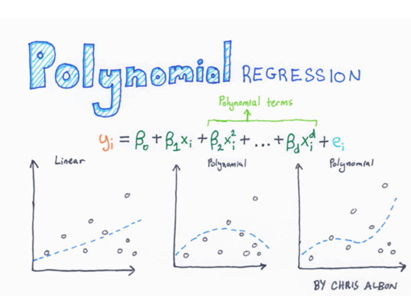

Poniżej skonstruowaliśmy wykres z dwiema zmiennymi, X i Y. Oczywiste jest, że związek nie jest liniowy. Jeśli dodamy regresję liniową, możemy zobaczyć, że model nie jest w stanie uchwycić wzoru (lewy obraz).

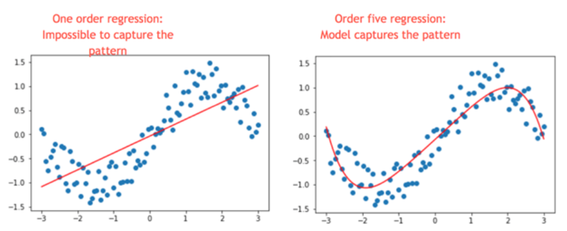

##### Tworzenie zmiennej syntetycznej w postaci kwadratu zmiennej 'age'

Wiek nie ma związku liniowego z dochodami. Wczesny wiek może mieć stały dochód bliski zeru, ponieważ dzieci lub młodzi ludzie nie pracują. Następnie zwiększa się w wieku produkcyjnym i maleje podczas przechodzenia na emeryturę. Zazwyczaj jest to kształt odwrócony-U. Jednym ze sposobów na uchwycenie tego wzorca jest dodanie potęgi drugiej do regresji.

Zobaczmy, czy zwiększy to dokładność.

Musisz dodać tę nową funkcję do zestawu danych i na liście funkcji ciągłej.

Dodajesz nową zmienną do zestawu danych treningowych i testowych, więc wygodniej jest napisać funkcję.

```python
def square_var(df_t, df_te, var_name = 'age'):
    df_t['new'] = df_t[var_name].pow(2)
    df_te['new'] = df_te[var_name].pow(2)
    return df_t, df_te
```

### Funkcja definiuje pojawienie się kolumny 'new' w biorze testowymi i zbiorze treningowym

Funkcja ma 3 argumenty:

df_t: zdefiniuj zestaw treningowy df_te: zdefiniuj zestaw testowy var_name = 'age': Zdefiniuj zmienną do transformacji Możesz użyć obiektu pow (2) do kwadratu zmiennej wiek. Zauważ, że nowa zmienna nosi nazwę „nowa”

Teraz, gdy została napisana funkcja square_var, możesz tworzyć nowe zestawy danych.

```python
df_train_new, df_test_new = square_var(df_train, df_test, var_name = 'age')
```

Jak widać, nowy zestaw danych ma jeszcze jedną funkcję.

```python
print (df_train_new.shape, df_test_new.shape)
```

```
(32561, 16) (16281, 16)
```

Nową zmienną syntetyczną tz. zmienną 'age' podniesioną do kwadratu nazywa się 'new' w zbiorze danych. Musisz dodać go do listy zmiennych ciągłych.

```python
CONTI_FEATURES_NEW  = ['age', 'fnlwgt','capital_gain', 'education_num', 'capital_loss', 'hours_week', 'new']
continuous_features_new = [tf.feature_column.numeric_column(k) for k in CONTI_FEATURES_NEW]
```

Pamiętaj , że zmieniłeś katalog wykresu. Nie można trenować różnych modeli w tym samym katalogu. Oznacza to, że musisz zmienić ścieżkę argumentu model_dir (ongoing/FOKA). Jeśli tego nie zrobisz, TensorFlow zgłosi błąd.

```python
model_1 = tf.estimator.LinearClassifier(
    model_dir="ongoing/FOKA",
    feature_columns=categorical_features+ continuous_features_new)
```

```
INFO:tensorflow:Using default config.
INFO:tensorflow:Using config: {'_model_dir': 'ongoing/FOKA', '_tf_random_seed': None, '_save_summary_steps': 100, '_save_checkpoints_steps': None, '_save_checkpoints_secs': 600, '_session_config': None, '_keep_checkpoint_max': 5, '_keep_checkpoint_every_n_hours': 10000, '_log_step_count_steps': 100,…
```

```python
model_1
```

```
<tensorflow.python.estimator.canned.linear.LinearClassifier at 0x1645a02de10>
```

```python
df_train.columns
```

```
Index(['age', 'workclass', 'fnlwgt', 'education', 'education_num', 'marital',
       'occupation', 'relationship', 'race', 'sex', 'capital_gain',
       'capital_loss', 'hours_week', 'native_country', 'label', 'new'],
      dtype='object')
```

model_1.train(input_fn=get_input_fn(df_train, num_epochs=None, n_batch = 128, shuffle=False), steps=1000)

```python
model.train(input_fn=get_input_fn(df_train,
                                      num_epochs=None,
                                      n_batch = 128,
                                      shuffle=False),
                                      steps=1000)
```

```
INFO:tensorflow:Create CheckpointSaverHook.
INFO:tensorflow:Restoring parameters from ongoing/train\model.ckpt-7000
INFO:tensorflow:Saving checkpoints for 7001 into ongoing/train\model.ckpt.
INFO:tensorflow:loss = 30489.328, step = 7001
INFO:tensorflow:global_step/sec: 143.035
INFO:tensorflow:loss = 7733.5723, step = 7101 (0.704 sec)
INFO:tensorflow:global_step/sec: 220.368
INFO:tensorflow:loss = 2901.3984, step = 7201 (0.460 sec)
INFO:tensorflow:global_step/sec: 221.831
INFO:tensorflow:loss = 22429.865, step = 7301 (0.445 sec)
INFO:tensorflow:global_step/sec: 226.338
INFO:tensorflow:loss = 2002.65, step = 7401 (0.442 sec)
INFO:tensorflow:global_step/sec: 217.973
INFO:tensorflow:loss = 1791.7544, step = 7501 (0.460 sec)
INFO:tensorflow:global_step/sec: 221.864
INFO:tensorflow:loss = 4016.9438, step = 7601 (0.451 sec)
INFO:tensorflow:global_step/sec: 243.368
INFO:tensorflow:loss = 6891.272, step = 7701 (0.409 sec)
INFO:tensorflow:global_step/sec: 235.37
INFO:tensorflow:loss = 5182.716, step = 7801 (0.427 sec)
INFO:tensorflow:global_step/sec: 222.323
INFO:tensorflow:loss = 19965.098, step = 7901 (0.449 sec)
INFO:tensorflow:Saving checkpoints for 8000 into ongoing/train\model.ckpt.
INFO:tensorflow:Loss for final step: 4179.0107.
```

```
<tensorflow.python.estimator.canned.linear.LinearClassifier at 0x16456e65cf8>
```

```python
model.train(input_fn=get_input_fn(df_test,
                                      num_epochs=None,
                                      n_batch = 128,
                                      shuffle=False),
                                      steps=1000)
```

```
INFO:tensorflow:Create CheckpointSaverHook.
INFO:tensorflow:Restoring parameters from ongoing/train\model.ckpt-8000
INFO:tensorflow:Saving checkpoints for 8001 into ongoing/train\model.ckpt.
INFO:tensorflow:loss = 20187.318, step = 8001
INFO:tensorflow:global_step/sec: 126.522
INFO:tensorflow:loss = 5441.968, step = 8101 (0.798 sec)
INFO:tensorflow:global_step/sec: 130.591
INFO:tensorflow:loss = 4129.809, step = 8201 (0.765 sec)
INFO:tensorflow:global_step/sec: 195.453
INFO:tensorflow:loss = 9977.4, step = 8301 (0.509 sec)
INFO:tensorflow:global_step/sec: 142.226
INFO:tensorflow:loss = 2719.969, step = 8401 (0.701 sec)
INFO:tensorflow:global_step/sec: 211.089
INFO:tensorflow:loss = 7430.4297, step = 8501 (0.476 sec)
INFO:tensorflow:global_step/sec: 225.829
INFO:tensorflow:loss = 16909.482, step = 8601 (0.444 sec)
INFO:tensorflow:global_step/sec: 220.368
INFO:tensorflow:loss = 16402.836, step = 8701 (0.454 sec)
INFO:tensorflow:global_step/sec: 233.724
INFO:tensorflow:loss = 3283.9873, step = 8801 (0.427 sec)
INFO:tensorflow:global_step/sec: 233.18
INFO:tensorflow:loss = 5073.4287, step = 8901 (0.429 sec)
INFO:tensorflow:Saving checkpoints for 9000 into ongoing/train\model.ckpt.
INFO:tensorflow:Loss for final step: 23220.023.
```

```
<tensorflow.python.estimator.canned.linear.LinearClassifier at 0x16456e65cf8>
```

## Sprawdzenie zbioru testowego

```python
model.evaluate(input_fn=get_input_fn(df_test,
                                      num_epochs=1,
                                      n_batch = 128,
                                      shuffle=False),
                                      steps=1000)
```

```
INFO:tensorflow:Starting evaluation at 2019-12-10-20:54:46
INFO:tensorflow:Restoring parameters from ongoing/train\model.ckpt-9000
INFO:tensorflow:Evaluation [100/1000]
INFO:tensorflow:Finished evaluation at 2019-12-10-20:54:48
INFO:tensorflow:Saving dict for global step 9000: accuracy = 0.7930717, accuracy_baseline = 0.76377374, auc = 0.5749365, auc_precision_recall = 0.58821106, average_loss = 88.92237, global_step = 9000, label/mean = 0.23622628, loss = 11310.509, prediction/mean = 0.045729272
```

```
{'accuracy': 0.7930717,
 'accuracy_baseline': 0.76377374,
 'auc': 0.5749365,
 'auc_precision_recall': 0.58821106,
 'average_loss': 88.92237,
 'label/mean': 0.23622628,
 'loss': 11310.509,
 'prediction/mean': 0.045729272,
 'global_step': 9000}
```

```python
Są jeszcze dwie kolejne metody poprawy modelu klasyfikatora liniowego
```

ULEPSZANIE MODELU

# Sposób 2: Podzielenie zmiennej ciągłą na zmienną jakościową

# >>> Bucketization

Funkcja: wiadrowania lub inaczej tworzenie klas w obrębie zmiennej ciągłej

Jak widzieliście wcześniej, liniowy klasyfikator nie jest w stanie poprawnie uchwycić wzorca wieku i dochodu. To dlatego, że uczy się pojedynczej wagi dla każdej funkcji. Aby ułatwić klasyfikatorowi, jedną z rzeczy, które możesz zrobić, jest umieszczenie tej funkcji w wiadrze. Wiadro przekształca funkcję numeryczną w kilka określonych na podstawie zakresu, w którym się mieści, a każda z tych nowych funkcji wskazuje, czy wiek osoby mieści się w tym zakresie.

Dzięki tym nowym funkcjom model liniowy może uchwycić związek, ucząc się różnych wag dla każdego segmentu.

### Dzielimy zmienną ciągłą 'age' na grupy wiekowe: [18, 25, 30, 35, 40, 45, 50, 55, 60, 65]

```python
age = tf.feature_column.numeric_column('age')
age_buckets = tf.feature_column.bucketized_column(
    age, boundaries=[18, 25, 30, 35, 40, 45, 50, 55, 60, 65])
```

## >>> Tworzenie zmiennej syntetycznej z interakcji pomiędzy zmiennymi niezależnymi

Funkcja: interakcji

Wiesz już, że wiek nie jest liniowy z dochodami. Innym sposobem na ulepszenie modelu jest interakcja (interaction). Według TensorFlow jest to skrzyżowanie funkcji. Przekraczanie cech jest sposobem na tworzenie nowych cech, które są kombinacjami istniejących, które mogą być pomocne dla klasyfikatora liniowego, który nie może modelować interakcji między cechami.

Wiek możesz podzielić według innej funkcji, takiej jak edukacja. Oznacza to, że niektóre grupy mogą mieć wysokie dochody, a inne niskie (Pomyśl o doktoracie).

Sposób na tworzenie nowych zmiennych, które są kombinacjami istniejących, które mogą być pomocne dla klasyfikatora liniowego, który pierwotnie nie może modelować interakcji między cechami.

Interakcja: 'education'-'occupation'

```python
education_x_occupation = [tf.feature_column.crossed_column(
    ['education', 'occupation'], hash_bucket_size=1000)]
```

age_buckets musi zostać podniesiony do kwadratu, aby dodać go do kolumn funkcji. Dlaczego? nie widać tego w kodzie

Interakcja: age_buckets, 'education', 'occupation'

```python
age_buckets_x_education_x_occupation = [tf.feature_column.crossed_column(
    [age_buckets, 'education', 'occupation'], hash_bucket_size=1000)]
```

Ważne uwagi:

- Rozmiar hash_bucket_size wskazuje maksymalne możliwości przekraczania.
- Aby utworzyć interakcję między zmiennymi przynajmniej jedna zmienna musi być kategoryczna)
- hash_bucket_size = 1000 ustawiamy na 1000, ponieważ nie znasz dokładnej liczby grup

## Wrzucenie wszystkiego do klasyfikatora liniowego Tensorflow

1. categorical_features - to dotychczasowe zmienne
2. base_columns to podział age na grupy wiekowe zrobione przez funkcje: bucketized_column
3. to są zmienne uzyskane jako interakcja wybranych cech
4. to są zmienne uzyskane jako interakcja wybranych cech

```python
base_columns = [age_buckets,]

model_imp = tf.estimator.LinearClassifier(
    model_dir="ongoing/train8",
    feature_columns=categorical_features+base_columns+education_x_occupation+age_buckets_x_education_x_occupation)
```

```
INFO:tensorflow:Using default config.
INFO:tensorflow:Using config: {'_model_dir': 'ongoing/train8', '_tf_random_seed': None, '_save_summary_steps': 100, '_save_checkpoints_steps': None, '_save_checkpoints_secs': 600, '_session_config': None, '_keep_checkpoint_max': 5, '_keep_checkpoint_every_n_hours': 10000, '_log_step_count_steps': 10…
```

model_imp - to jest zbiór dotchczasowych ziennych i nowych zmiennych wszystko przebrobione na TensorFLow tensory

```python
model_imp.train(input_fn=get_input_fn(df_train_new,
                                      num_epochs=None,
                                      n_batch = 128,
                                      shuffle=False),
                                      steps=1000)
```

```
INFO:tensorflow:Create CheckpointSaverHook.
INFO:tensorflow:Restoring parameters from ongoing/train8\model.ckpt-3000
INFO:tensorflow:Saving checkpoints for 3001 into ongoing/train8\model.ckpt.
INFO:tensorflow:loss = 51.4327, step = 3001
INFO:tensorflow:global_step/sec: 143.71
INFO:tensorflow:loss = 48.391304, step = 3101 (0.701 sec)
INFO:tensorflow:global_step/sec: 197.767
INFO:tensorflow:loss = 50.023735, step = 3201 (0.504 sec)
INFO:tensorflow:global_step/sec: 150.752
INFO:tensorflow:loss = 43.08108, step = 3301 (0.668 sec)
INFO:tensorflow:global_step/sec: 150.006
INFO:tensorflow:loss = 36.135357, step = 3401 (0.663 sec)
INFO:tensorflow:global_step/sec: 221.341
INFO:tensorflow:loss = 55.94835, step = 3501 (0.453 sec)
INFO:tensorflow:global_step/sec: 225.242
INFO:tensorflow:loss = 31.514946, step = 3601 (0.442 sec)
INFO:tensorflow:global_step/sec: 228.921
INFO:tensorflow:loss = 37.521355, step = 3701 (0.438 sec)
INFO:tensorflow:global_step/sec: 232.64
INFO:tensorflow:loss = 59.80222, step = 3801 (0.430 sec)
INFO:tensorflow:global_step/sec: 231.565
INFO:tensorflow:loss = 42.907143, step = 3901 (0.432 sec)
INFO:tensorflow:Saving checkpoints for 4000 into ongoing/train8\model.ckpt.
INFO:tensorflow:Loss for final step: 44.19162.
```

```
<tensorflow.python.estimator.canned.linear.LinearClassifier at 0x16458628cc0>
```

### Teraz sprawdzam jaki liczy nowy model po ulepszeniach

```python
model_imp.evaluate(input_fn=get_input_fn(df_test_new,
                                      num_epochs=1,
                                      n_batch = 128,
                                      shuffle=False),
                                      steps=1000)
```

```
INFO:tensorflow:Starting evaluation at 2019-12-10-21:08:49
INFO:tensorflow:Restoring parameters from ongoing/train8\model.ckpt-4000
INFO:tensorflow:Evaluation [100/1000]
INFO:tensorflow:Finished evaluation at 2019-12-10-21:08:50
INFO:tensorflow:Saving dict for global step 4000: accuracy = 0.8348996, accuracy_baseline = 0.76377374, auc = 0.8816793, auc_precision_recall = 0.6916487, average_loss = 0.35485023, global_step = 4000, label/mean = 0.23622628, loss = 45.135284, prediction/mean = 0.23636246
```

```
{'accuracy': 0.8348996,
 'accuracy_baseline': 0.76377374,
 'auc': 0.8816793,
 'auc_precision_recall': 0.6916487,
 'average_loss': 0.35485023,
 'label/mean': 0.23622628,
 'loss': 45.135284,
 'prediction/mean': 0.23636246,
 'global_step': 4000}
```

Model klasyfikatora liniowego poprawił się z 'accuracy': 0.78348994 do 'accuracy': 0.8348996. Powierzchnia AUX z 0.54725313 do 0.8816793

# Hyperparameter:Lasso & Ridge

## Add regularization parameter

Twój model może cierpieć z przeuczenia lub niedouczenia (overfitting or underfitting) .

### overfitting: model nie jest w stanie uogólnić prognozy na nowe dane

### underfitting: Niedopasowanie : model nie może przechwycić wzorca danych. np. regresja liniowa, gdy dane są nieliniowe

Aby zapobiec nadmiernemu dopasowaniu (overfitting), regularyzacja daje możliwość kontrolowania takiej złożoności i czyni ją bardziej uogólnioną. Istnieją dwie techniki regularyzacji:

```
L1: Lasso
L2: Ridge
```

W TensorFlow możesz dodać te dwa hiperparametry w optymalizatorze.

Na przykład, im wyższy jest hiperparametr L2: Ridge, waga jest zwykle bardzo niska i bliska zeru. Dopasowana linia będzie bardzo płaska, podczas gdy

L2 bliskie zeru oznacza, że wagi są bliskie regularnej regresji liniowej.

Możesz samodzielnie ręcznie, wypróbować inną wartość hiperparametrów i sprawdzić, czy możesz zwiększyć poziom dokładności.

Pamiętaj, że jeśli zmienisz hiperparametr, musisz usunąć folder obecny / train4 zmienić jego nazwę, w przeciwnym razie model rozpocznie się od wcześniej wyuczonego modelu.

Twprzymyu z udziałęm L1 i L2 nowy model - model_regu gdzie:

```
   -   L1 = 0.9
   -   L2 = 5
```

```python
model_regu = tf.estimator.LinearClassifier(
    model_dir="ongoing/train4", feature_columns=categorical_features+base_columns+education_x_occupation+age_buckets_x_education_x_occupation,
    optimizer=tf.train.FtrlOptimizer(
        learning_rate=0.1,
        l1_regularization_strength=0.9,
        l2_regularization_strength=5))
```

```
INFO:tensorflow:Using default config.
INFO:tensorflow:Using config: {'_model_dir': 'ongoing/train4', '_tf_random_seed': None, '_save_summary_steps': 100, '_save_checkpoints_steps': None, '_save_checkpoints_secs': 600, '_session_config': None, '_keep_checkpoint_max': 5, '_keep_checkpoint_every_n_hours': 10000, '_log_step_count_steps': 10…
```

Trenuje ten model

```python
model_regu.train(input_fn=get_input_fn(df_train_new,
                                      num_epochs=None,
                                      n_batch = 128,
                                      shuffle=False),
                                      steps=1000)
```

```
INFO:tensorflow:Create CheckpointSaverHook.
INFO:tensorflow:Saving checkpoints for 1 into ongoing/train4\model.ckpt.
INFO:tensorflow:loss = 88.72288, step = 1
INFO:tensorflow:global_step/sec: 91.9953
INFO:tensorflow:loss = 50.38778, step = 101 (1.089 sec)
INFO:tensorflow:global_step/sec: 213.79
INFO:tensorflow:loss = 55.38014, step = 201 (0.469 sec)
INFO:tensorflow:global_step/sec: 210.845
INFO:tensorflow:loss = 46.806694, step = 301 (0.475 sec)
INFO:tensorflow:global_step/sec: 189.195
INFO:tensorflow:loss = 38.682713, step = 401 (0.530 sec)
INFO:tensorflow:global_step/sec: 183.926
INFO:tensorflow:loss = 56.99398, step = 501 (0.542 sec)
INFO:tensorflow:global_step/sec: 230.5
INFO:tensorflow:loss = 33.263622, step = 601 (0.434 sec)
INFO:tensorflow:global_step/sec: 235.924
INFO:tensorflow:loss = 37.7902, step = 701 (0.425 sec)
INFO:tensorflow:global_step/sec: 138.466
INFO:tensorflow:loss = 61.73261, step = 801 (0.724 sec)
INFO:tensorflow:global_step/sec: 200.999
INFO:tensorflow:loss = 46.938225, step = 901 (0.498 sec)
INFO:tensorflow:Saving checkpoints for 1000 into ongoing/train4\model.ckpt.
INFO:tensorflow:Loss for final step: 43.4942.
```

```
<tensorflow.python.estimator.canned.linear.LinearClassifier at 0x164584e67b8>
```

Oceniam ten model

```python
model_regu.evaluate(input_fn=get_input_fn(df_test_new,
                                      num_epochs=1,
                                      n_batch = 128,
                                      shuffle=False),
                                      steps=1000)
```

```
INFO:tensorflow:Starting evaluation at 2019-12-10-21:28:46
INFO:tensorflow:Restoring parameters from ongoing/train4\model.ckpt-1000
INFO:tensorflow:Evaluation [100/1000]
INFO:tensorflow:Finished evaluation at 2019-12-10-21:28:47
INFO:tensorflow:Saving dict for global step 1000: accuracy = 0.83833915, accuracy_baseline = 0.76377374, auc = 0.8869794, auc_precision_recall = 0.7014905, average_loss = 0.34691378, global_step = 1000, label/mean = 0.23622628, loss = 44.12581, prediction/mean = 0.2366209
```

```
{'accuracy': 0.83833915,
 'accuracy_baseline': 0.76377374,
 'auc': 0.8869794,
 'auc_precision_recall': 0.7014905,
 'average_loss': 0.34691378,
 'label/mean': 0.23622628,
 'loss': 44.12581,
 'prediction/mean': 0.2366209,
 'global_step': 1000}
```

Poprawa do ostatniego stanu z 'accuracy': 0.8348996 do 'accuracy': 0.83833915

Zmiana Parametrów L1 i L2

```
-   L1 = 0.5
-   L2 = 7
```

```python
model_regu2 = tf.estimator.LinearClassifier(
    model_dir="ongoing/train5", feature_columns=categorical_features+base_columns+education_x_occupation+age_buckets_x_education_x_occupation,
    optimizer=tf.train.FtrlOptimizer(
        learning_rate=0.1,
        l1_regularization_strength=0.5,
        l2_regularization_strength=7))
```

```
INFO:tensorflow:Using default config.
INFO:tensorflow:Using config: {'_model_dir': 'ongoing/train5', '_tf_random_seed': None, '_save_summary_steps': 100, '_save_checkpoints_steps': None, '_save_checkpoints_secs': 600, '_session_config': None, '_keep_checkpoint_max': 5, '_keep_checkpoint_every_n_hours': 10000, '_log_step_count_steps': 10…
```

```python
model_regu2.train(input_fn=get_input_fn(df_train_new,
                                      num_epochs=None,
                                      n_batch = 128,
                                      shuffle=False),
                                      steps=1000)
```

```
INFO:tensorflow:Create CheckpointSaverHook.
INFO:tensorflow:Restoring parameters from ongoing/train5\model.ckpt-1000
INFO:tensorflow:Saving checkpoints for 1001 into ongoing/train5\model.ckpt.
INFO:tensorflow:loss = 51.02873, step = 1001
INFO:tensorflow:global_step/sec: 157.159
INFO:tensorflow:loss = 49.492256, step = 1101 (0.639 sec)
INFO:tensorflow:global_step/sec: 222.817
INFO:tensorflow:loss = 51.96578, step = 1201 (0.449 sec)
INFO:tensorflow:global_step/sec: 222.323
INFO:tensorflow:loss = 44.7421, step = 1301 (0.452 sec)
INFO:tensorflow:global_step/sec: 224.687
INFO:tensorflow:loss = 37.318436, step = 1401 (0.442 sec)
INFO:tensorflow:global_step/sec: 231.565
INFO:tensorflow:loss = 56.40531, step = 1501 (0.436 sec)
INFO:tensorflow:global_step/sec: 205.907
INFO:tensorflow:loss = 32.425224, step = 1601 (0.486 sec)
INFO:tensorflow:global_step/sec: 200.535
INFO:tensorflow:loss = 37.318344, step = 1701 (0.496 sec)
INFO:tensorflow:global_step/sec: 211.982
INFO:tensorflow:loss = 61.2978, step = 1801 (0.473 sec)
INFO:tensorflow:global_step/sec: 202.259
INFO:tensorflow:loss = 45.809494, step = 1901 (0.493 sec)
INFO:tensorflow:Saving checkpoints for 2000 into ongoing/train5\model.ckpt.
INFO:tensorflow:Loss for final step: 43.42147.
```

```
<tensorflow.python.estimator.canned.linear.LinearClassifier at 0x1645f2244a8>
```

```python
model_regu2.evaluate(input_fn=get_input_fn(df_test_new,
                                      num_epochs=1,
                                      n_batch = 128,
                                      shuffle=False),
                                      steps=1000)
```

```
INFO:tensorflow:Starting evaluation at 2019-12-10-21:33:30
INFO:tensorflow:Restoring parameters from ongoing/train5\model.ckpt-2000
INFO:tensorflow:Evaluation [100/1000]
INFO:tensorflow:Finished evaluation at 2019-12-10-21:33:32
INFO:tensorflow:Saving dict for global step 2000: accuracy = 0.83741784, accuracy_baseline = 0.76377374, auc = 0.88643366, auc_precision_recall = 0.70076597, average_loss = 0.34776637, global_step = 2000, label/mean = 0.23622628, loss = 44.234253, prediction/mean = 0.23740724
```

```
{'accuracy': 0.83741784,
 'accuracy_baseline': 0.76377374,
 'auc': 0.88643366,
 'auc_precision_recall': 0.70076597,
 'average_loss': 0.34776637,
 'label/mean': 0.23622628,
 'loss': 44.234253,
 'prediction/mean': 0.23740724,
 'global_step': 2000}
```

Zmiana parametrów spowodowałą pogorszenie parametrów modelu